# Chapter Notes

These notes follow the book [Bayesian Networks with Examples in R](https://www.bnlearn.com/book-crc-2ed/) by Marco Scutari and Jean Baptiste Denis.

```r
library(lattice)
library(gridExtra)
library(gRain)
library(Rgraphviz)
library(bnlearn)
```

# Chapter 1

## Train-Use Survey Example

### Variables

- Age (A): the age, recorded as young (young) for individuals below 30 years old, adult (adult) for individuals between 30 and 60 years old, and old (old) for people older than 60.
- Sex (S): the biological sex, recorded as male (M) or female (F).
- Education (E): the highest level of education or training successfully completed, recorded as up to high school (high) or university degree (uni).
- Occupation (O): whether the individual is an employee (emp) or a selfemployed (self) worker.
- Residence (R): the size of the city the individual lives in, recorded as either small (small) or big (big).
- Travel (T): the means of transport favoured by the individual, recorded either as car (car), train (train) or other (other).

### Basic Model

Here we establish the basic directed acyclical graph (DAG)

```r
#Nodes
dag <- empty.graph(nodes = c("A", "S", "E", "O", "R", "T"))

#Arcs
dag <- set.arc(dag, from = "A", to = "E")
dag <- set.arc(dag, from = "S", to = "E")
dag <- set.arc(dag, from = "E", to = "O")
dag <- set.arc(dag, from = "E", to = "R")
dag <- set.arc(dag, from = "O", to = "T")
dag <- set.arc(dag, from = "R", to = "T")
dag
```

```
##
##   Random/Generated Bayesian network
##
##   model:
##    [A][S][E|A:S][O|E][R|E][T|O:R]
##   nodes:                                 6
##   arcs:                                  6
##     undirected arcs:                     0
##     directed arcs:                       6
##   average markov blanket size:           2.67
##   average neighbourhood size:            2.00
##   average branching factor:              1.00
##
##   generation algorithm:                  Empty
```

### Creating Probability Tables from Subject Matter Expert Elicitation

One way to generate a conditional probability table is to elecit subjective probabilities from experts. Below is the method to do this in the `bnlearn` package.

```r
#level sets
A.lv <- c("young", "adult", "old")
S.lv <- c("M", "F")
E.lv <- c("high", "uni")
O.lv <- c("emp", "self")
R.lv <- c("small", "big")
T.lv <- c("car", "train", "other")

#Nodes A and S
A.prob <- array(c(0.30, 0.50, 0.20), dim = 3, dimnames = list(A = A.lv))
A.prob
```

```
## A
## young adult   old
##   0.3   0.5   0.2
```

```r
S.prob <- array(c(0.60, 0.40), dim = 2, dimnames = list(S = S.lv))
S.prob
```

```
## S
##   M   F
## 0.6 0.4
```

```r
#Nodes O and R
O.prob <- array(c(0.96, 0.04, 0.92, 0.08), dim = c(2, 2),
            dimnames = list(O = O.lv, E = E.lv))
O.prob
```

```
##       E
## O      high  uni
##   emp  0.96 0.92
##   self 0.04 0.08
```

```r
R.prob <- array(c(0.25, 0.75, 0.20, 0.80), dim = c(2, 2),
            dimnames = list(R = R.lv, E = E.lv))
R.prob
```

```
##        E
## R       high uni
##   small 0.25 0.2
##   big   0.75 0.8
```

```r
#Nodes E and T
E.prob <- array(c(0.75, 0.25, 0.72, 0.28, 0.88, 0.12, 0.64, 0.36, 0.70,
                  0.30, 0.90, 0.10), dim = c(2, 3, 2),
            dimnames = list(E = E.lv, A = A.lv, S = S.lv))

T.prob <- array(c(0.48, 0.42, 0.10, 0.56, 0.36, 0.08, 0.58, 0.24, 0.18,
                  0.70, 0.21, 0.09), dim = c(3, 2, 2),
            dimnames = list(T = T.lv, O = O.lv, R = R.lv))
```

#### Fit the Model

```r
cpt <- list(A = A.prob, S = S.prob, E = E.prob, O = O.prob, R = R.prob,
         T = T.prob)
bn <- custom.fit(dag, cpt)


#print-number-of-parameters
nparams(bn)
```

```
## [1] 21
```

```r
#print-arcs-fitted
arcs(bn)
```

```
##      from to
## [1,] "A"  "E"
## [2,] "S"  "E"
## [3,] "E"  "O"
## [4,] "E"  "R"
## [5,] "O"  "T"
## [6,] "R"  "T"
```

```r
#print-fitted-node-R
bn$R
```

```
##
##   Parameters of node R (multinomial distribution)
##
## Conditional probability table:
##
##        E
## R       high  uni
##   small 0.25 0.20
##   big   0.75 0.80
```

```r
#extract-probabilities-node-R
R.cpt <- coef(bn$R)
```

### Fitting a model from data

Conversely, we can also estimated the network parameters from a table of data.

#### Maximum Likelihood Method (pages 10-11)

In essence, this method builds proportion tables based on the number of observations within the data.

```r
#read-survey-data
survey <- read.table("data/survey.txt", header = TRUE, colClasses = "factor")


#head-survey-data
head(survey)
```

|  | A | R | E | O | S | T |
| --- | --- | --- | --- | --- | --- | --- |
| 1 | adult | big | high | emp | F | car |
| 2 | adult | small | uni | emp | M | car |
| 3 | adult | big | uni | emp | F | train |
| 4 | adult | big | high | emp | M | car |
| 5 | adult | big | high | emp | M | car |
| 6 | adult | small | high | emp | F | train |

```r
#maximum-likelihood-fit
bn.mle <- bn.fit(dag, data = survey, method = "mle")

#create-cpt-manually-O-E
prop.table(table(survey[, c("O", "E")]), margin = 2)
```

```
##       E
## O            high        uni
##   emp  0.98082192 0.92592593
##   self 0.01917808 0.07407407
```

```r
#print-O-from-fitted
bn.mle$O
```

```
##
##   Parameters of node O (multinomial distribution)
##
## Conditional probability table:
##
##       E
## O            high        uni
##   emp  0.98082192 0.92592593
##   self 0.01917808 0.07407407
```

# Risk Assessment Book Chapter 7

## Example 7.1

### Set up the model

```r
#Nodes
train_dag <- empty.graph(nodes = c("T", "N"))

#Arcs
train_dag <- set.arc(train_dag, from = "T", to = "N")

#level sets
T.lv <- c("False", "True")
N.lv <- c("False", "True")

#Probabilities
T.prob <- array(c(0.9, 0.1), dim = 2, dimnames = list(T = T.lv))
T.prob
```

```
## T
## False  True
##   0.9   0.1
```

```r
N.prob <- array(c(0.9, 0.1, 0.2, 0.8), dim = c(2, 2),
            dimnames = list(N = N.lv, T = T.lv))
N.prob
```

```
##        T
## N       False True
##   False   0.9  0.2
##   True    0.1  0.8
```

### Fit the Model

```r
train_cpt <- list(N = N.prob, T = T.prob)
train_bn <- custom.fit(train_dag, train_cpt)


#print-number-of-parameters
nparams(train_bn)
```

```
## [1] 3
```

```r
#print-arcs-fitted
arcs(train_bn)
```

```
##      from to
## [1,] "T"  "N"
```

```r
#print-fitted-node-N
train_bn$N
```

```
##
##   Parameters of node N (multinomial distribution)
##
## Conditional probability table:
##
##        T
## N       False True
##   False   0.9  0.2
##   True    0.1  0.8
```

```r
#extract-probabilities-node-R
train_N.cpt <- coef(train_bn$N)
train_N.cpt
```

```
##        T
## N       False True
##   False   0.9  0.2
##   True    0.1  0.8
```

### Extract Probabilities

```r
junction <- compile(as.grain(train_bn))
```

#### Q1. What is the marginal unconditional probability that Norman is late?

```r
querygrain(junction, nodes = "N")$N
```

```
## N
## False  True
##  0.83  0.17
```

Based on the model Norman has a $17\%$ chance of being late. You can calculate this by hand by doing the following:

$$\begin{align}
P(N = True) &= P(N = True | T = True)P(T = True) + P(N = True | T = False)P(T = False)\\
&= 0.8 \times 0.1 + 0.1 \times 0.9\\
&= 0.17
\end{align}$$

##### View the model

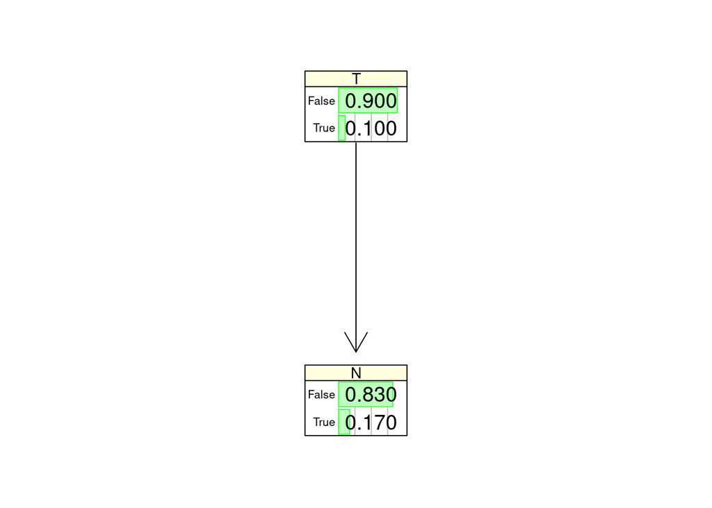

```r
graphviz.chart(train_bn, type = "barprob", grid = TRUE, bar.col = "green",
  strip.bg = "lightyellow")
```

#### Q2. What is the probability of a train strike given we observe Norman being late?

```r
strike_res <- setEvidence(junction, nodes = "N", states = "True")
querygrain(strike_res, nodes = "T")$T
```

```
## T
##     False      True
## 0.5294118 0.4705882
```

Thus, knowing that Norman is late leads to an increase in probability of a train strike from $10\%$ to $47\%$. The calculation for this is:

$$\begin{align}
P(T = True | N = True) &= \frac{P(N = True | T = True)P(T = True)}{P(N = True)}\\
&= \frac{0.8 \times 0.1}{0.17}\\
&= 0.4705882
\end{align}$$

##### View the model

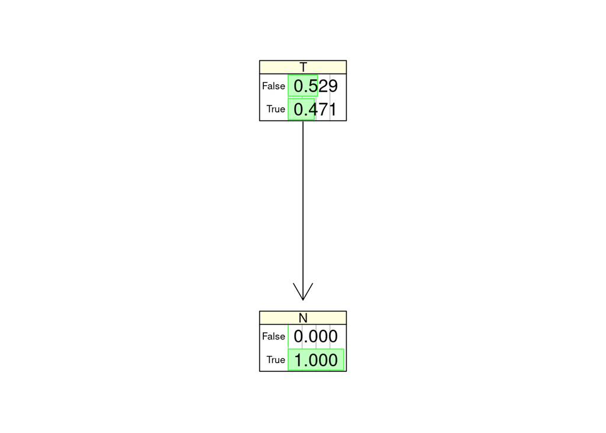

```r
graphviz.chart(as.bn.fit(strike_res, including.evidence = TRUE), type = "barprob", grid = TRUE, bar.col = "green",
  strip.bg = "lightyellow")
```

## Expanded Model

### Set up the model

```r
#Nodes
train_extended_dag <- empty.graph(nodes = c("O","T", "M", "N"))

#Arcs
train_arc_set <- matrix(c("O", "M",
                          "T", "M",
                          "T", "N"),
                        byrow = TRUE,
                        ncol = 2,
                        dimnames = list(NULL, c("from", "to")))
arcs(train_extended_dag) <- train_arc_set

#level sets
O.lv <- c("False", "True")
T.lv <- c("False", "True")
M.lv <- c("False", "True")
N.lv <- c("False", "True")

#Probabilities
O.prob <- array(c(0.6, 0.4), dim = 2, dimnames = list(O = O.lv))
O.prob
```

```
## O
## False  True
##   0.6   0.4
```

```r
T.prob <- array(c(0.9, 0.1), dim = 2, dimnames = list(T = T.lv))
T.prob
```

```
## T
## False  True
##   0.9   0.1
```

```r
M.prob <- array(c(0.7, 0.3, 0.4, 0.6, 0.4, 0.6, 0.2, 0.8), dim = c(2, 2, 2),
            dimnames = list(M = M.lv, T = T.lv, O = O.lv))
M.prob
```

```
## , , O = False
##
##        T
## M       False True
##   False   0.7  0.4
##   True    0.3  0.6
##
## , , O = True
##
##        T
## M       False True
##   False   0.4  0.2
##   True    0.6  0.8
```

```r
N.prob <- array(c(0.9, 0.1, 0.2, 0.8), dim = c(2, 2),
            dimnames = list(N = N.lv, T = T.lv))
N.prob
```

```
##        T
## N       False True
##   False   0.9  0.2
##   True    0.1  0.8
```

### Fit the Model

```r
train_extended_cpt <- list(N = N.prob, T = T.prob, O = O.prob, M = M.prob)
train_extended_bn <- custom.fit(train_extended_dag, train_extended_cpt)
```

##### View the model

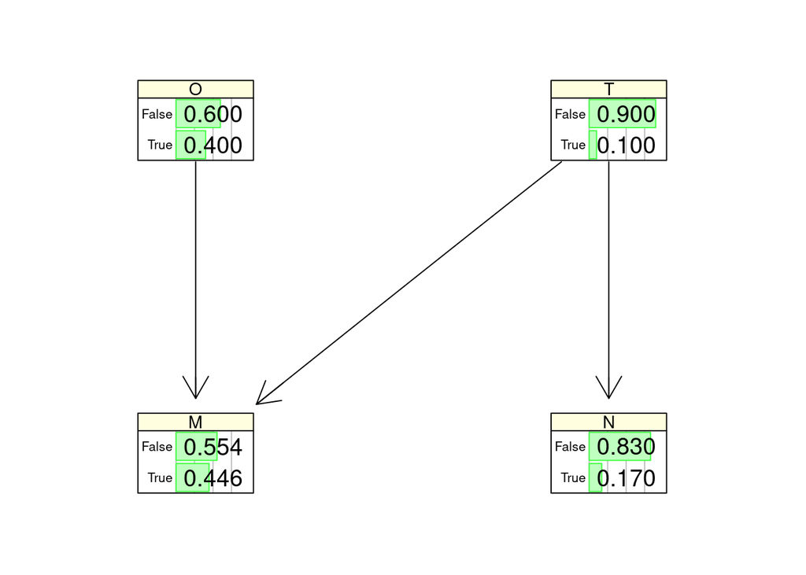

```r
graphviz.chart(train_extended_bn, type = "barprob", grid = TRUE, bar.col = "green",
  strip.bg = "lightyellow")
```

### What is the probability of Martin being late given evidence that Norman is late?

```r
extended_junction <- compile(as.grain(train_extended_bn))
norm_late <- setEvidence(extended_junction, nodes = "N", states = "True")
querygrain(norm_late, nodes = "M")$M
```

```
## M
##     False      True
## 0.4576471 0.5423529
```

##### View the model

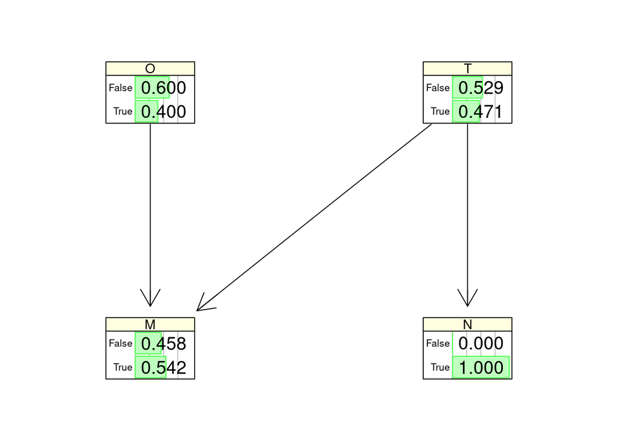

```r
graphviz.chart(as.bn.fit(norm_late, including.evidence = TRUE), type = "barprob", grid = TRUE, bar.col = "green",
  strip.bg = "lightyellow")
```

It is interesting to note that if we only know that Norman is late, then there is a chance that Martin is late as well and it is due to the strike due to the divergent connections these nodes have to the train strike node.

### What does the network look like if only Martin is late?

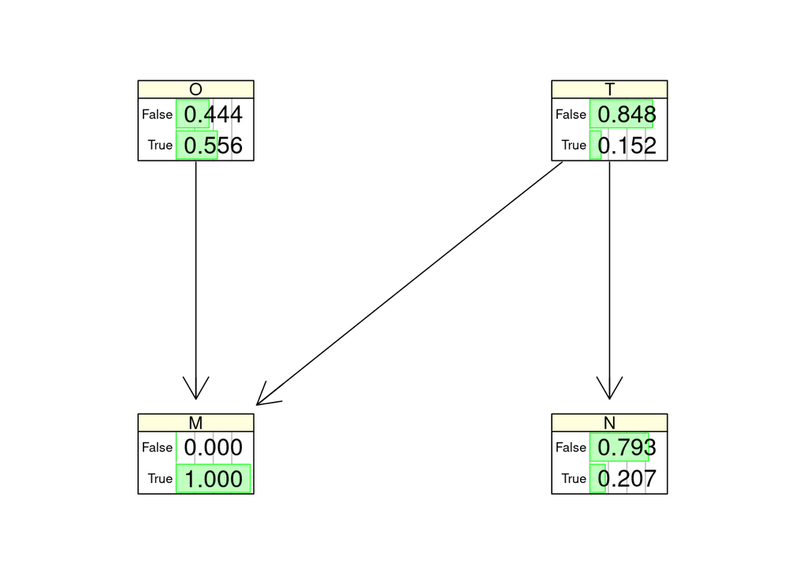

```r
martin_late <- setEvidence(extended_junction, nodes = "M", states = "True")
graphviz.chart(as.bn.fit(martin_late, including.evidence = TRUE), type = "barprob", grid = TRUE, bar.col = "green",
  strip.bg = "lightyellow")
```

Now if only Martin is late, the odds of a strike slightly increase, but the most likely reason he is late is oversleeping.

### What does the network look like if both Martin and Norman are late?

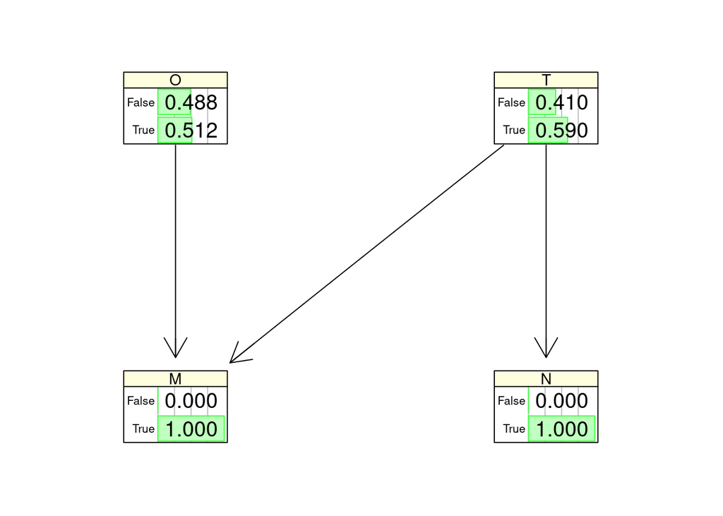

```r
both_late <- setEvidence(extended_junction, nodes = c("M","N"), states = c("True", "True"))
graphviz.chart(as.bn.fit(both_late, including.evidence = TRUE), type = "barprob", grid = TRUE, bar.col = "green",
  strip.bg = "lightyellow")
```

With both Martin and Norman being late, it is most likely that there was a train strike, however, we cannot fully eliminate that Martin could have overslept as well.